# Untitled

Daniel Briseno Servin

9/28/2020

# HW Lecture 5

## Question 1

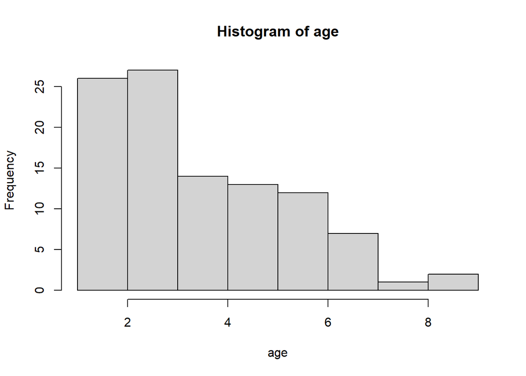

```r
hist(age)
```

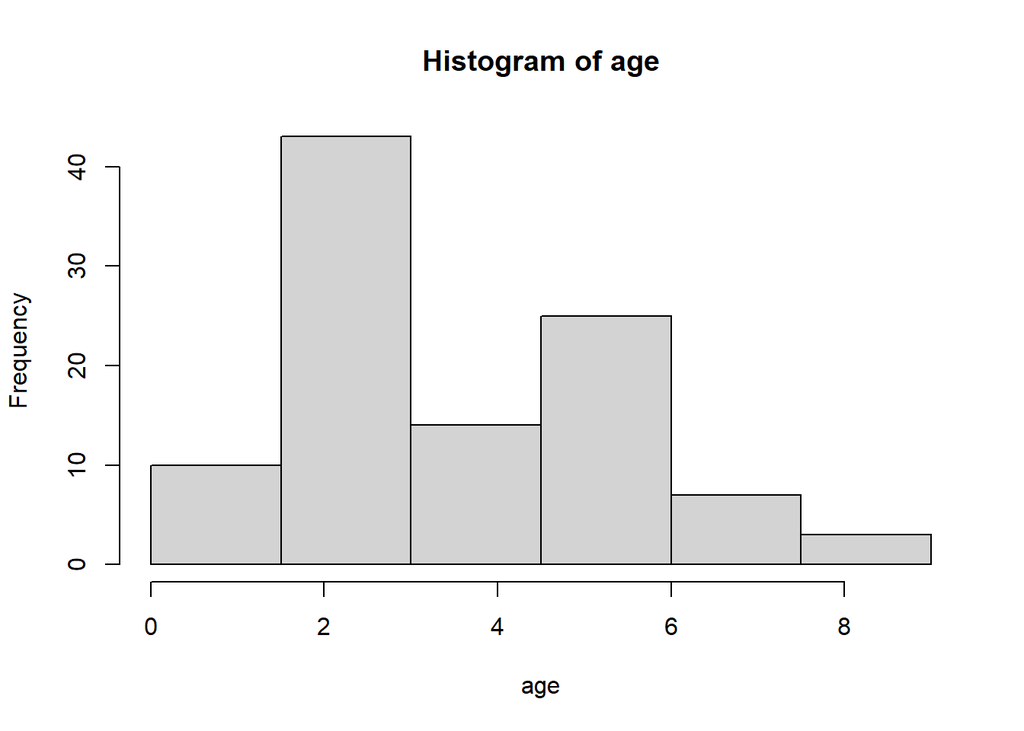

```r
hist(age, seq(0,9,1.5))
```

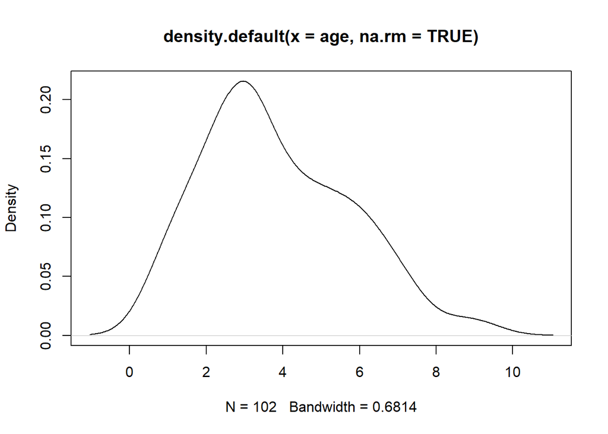

```r
plot(density(age,na.rm=TRUE))
```

The advantages of using the kernel density estimate is that it more clearly shows trends in the data. The trade-off is that you lose the finer-grained categorical picture shown in the histogram, which can lead a researcher to observe “trends” in the data which could be an artifact of the bandwith rather than a real trend.

## Question 2

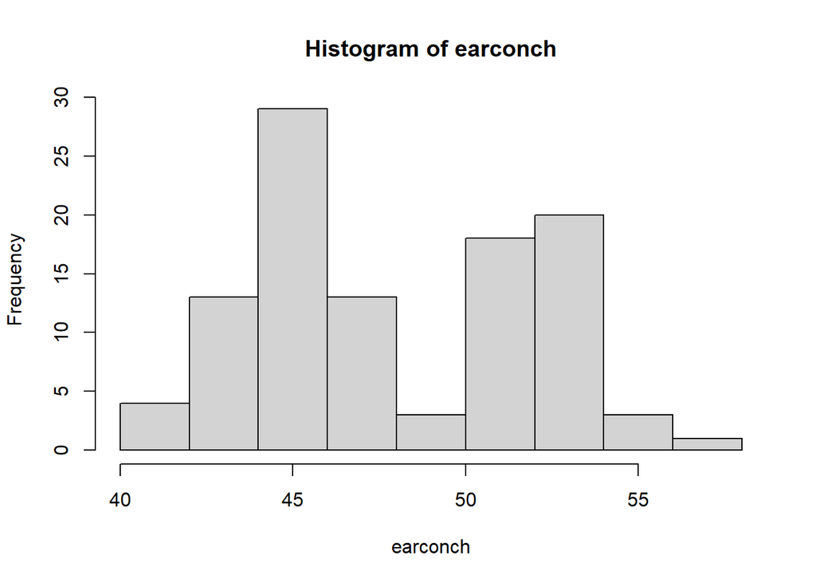

```r
hist(earconch)
```

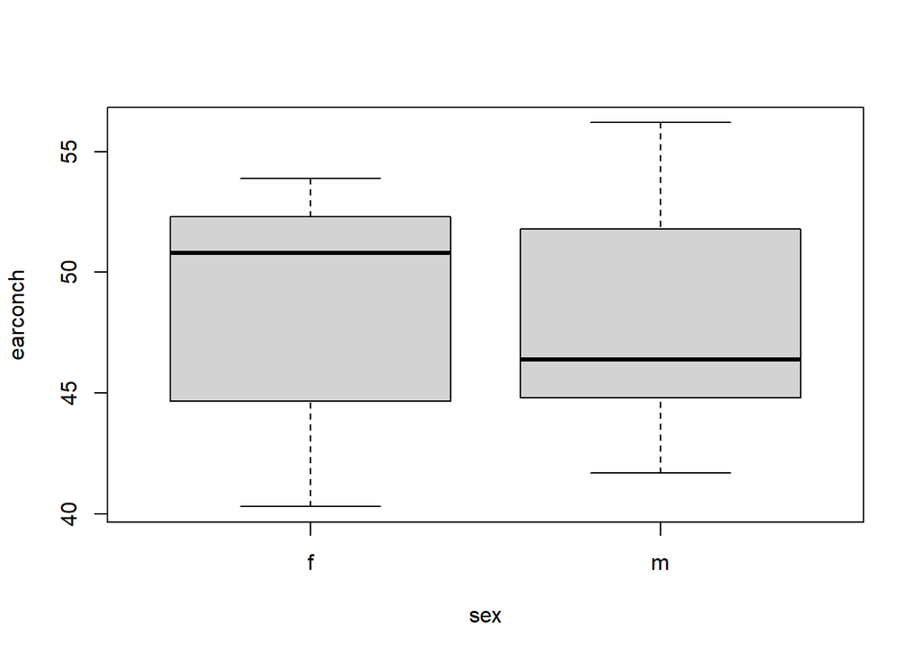

```r
boxplot(earconch~sex)
```

The histogram does indeed show that the data is bimodal, which could lead to suspicion of a 2-factor variable influencing ear conch size. The box-and-whisker plots show that while the interquartile range is not significantly different between males and females, females do have a higher median earconch size than males. Since the interquartile ranges are so similar, I suspect that more data analysis is needed to conclude that the differences in earconch median sizes is statistically significant.

## Question 3

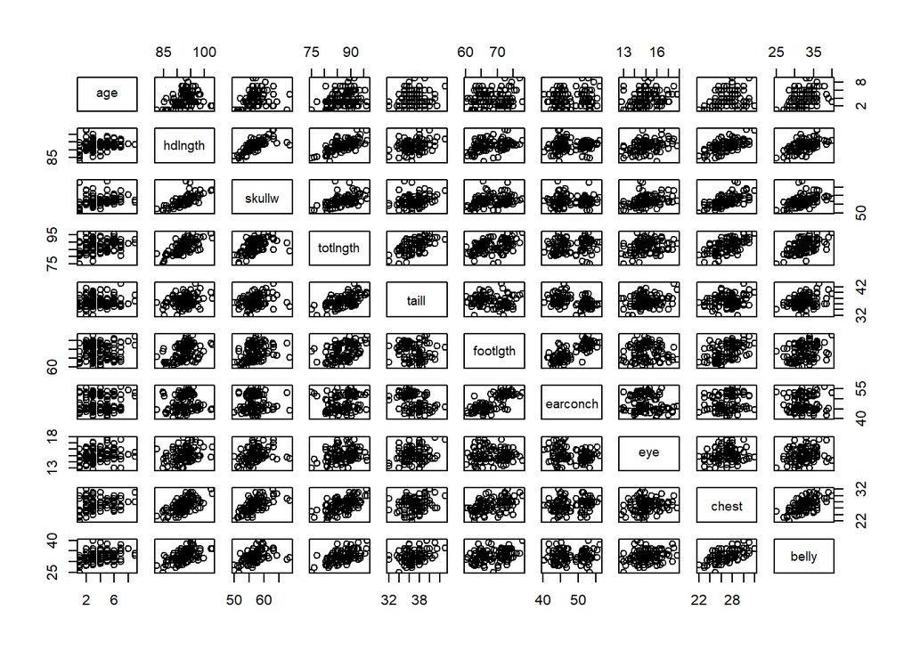

```r
pairs(~age+hdlngth+skullw+totlngth+taill+footlgth+earconch+eye+chest+belly, data=possum)
```

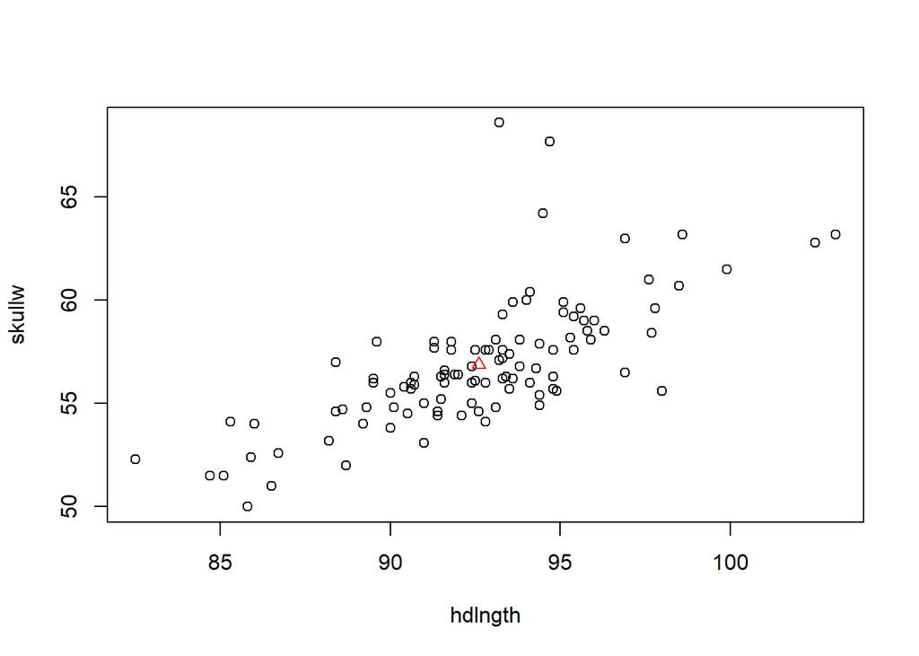

```r
plot(hdlngth,skullw)
points(mean(hdlngth),mean(skullw),pch=2,col="red")
```